# Survival Analysis of BCG Vaccination

Temi Adebayo

2022-12-28

In rural Guinea-Bissau, 5274 children under 7 months of age were visited two times at home with an interval of six months (Kristensen et al., BMJ, 2000). Information about vaccination (BCG, DTP, measles vaccine) was collected at each visit, and at the second visit, death during follow-up was registered. Some children moved away during follow-up, some survived until the next visit. The following variables are found in the data set bissau.dta:

- id: id number
- fuptime: follow-up time in days
- dead: 0 = censored, 1 = dead
- bcg: 1 = Yes, 0 = No
- dtp: number of DTP doses (0, 1, 2, 3)
- age: age at first visit in days

```r
library(haven)
library(survival)
library(survminer)
library(ggplot2)
library(tidyr)
library(MASS)
library(mice)

load("~/.RData")
#bissau_data <- read_dta("Github Projects/Data-analysis-and-visualization/Survival analysis/bissau.dta")
#View(bissau_data)

#categorize age(in days) into groups
max(bissau_data$age) #oldest is 7.1 months old
```

```
## [1] 212
```

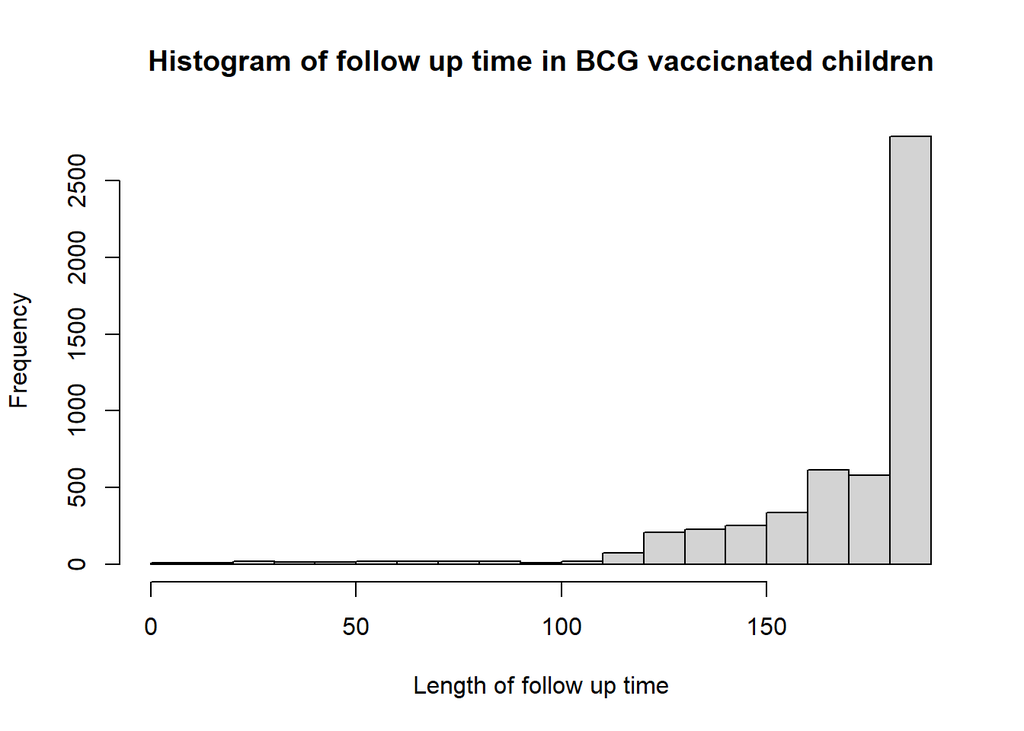

```r
hist(bissau_data$fuptime, xlab = "Length of follow up time", main = "Histogram of follow up time in BCG vaccicnated children")
```

```r
bissau_data$agegrp <- cut(bissau_data$age,
                          breaks = c(0,90,Inf),
                          labels = c("<3 months",">3 months"), include.lowest = TRUE)
```

```r
#specify first null model where fuptime is time to event,
#dead is censored variable
km_fit1 <- survfit(Surv(fuptime, dead)~ bcg,
                   data = bissau_data, type = "kaplan-meier")
print(km_fit1)
```

```
## Call: survfit(formula = Surv(fuptime, dead) ~ bcg, data = bissau_data,
##     type = "kaplan-meier")
##
##          n events median 0.95LCL 0.95UCL
## bcg=0 1973     97     NA      NA      NA
## bcg=1 3301    125     NA      NA      NA
```

```r
summary(km_fit1)$table
```

```
##       records n.max n.start events    rmean se(rmean) median 0.95LCL 0.95UCL
## bcg=0    1973  1973    1973     97 178.0043  0.548886     NA      NA      NA
## bcg=1    3301  3301    3301    125 179.7286  0.324888     NA      NA      NA
```

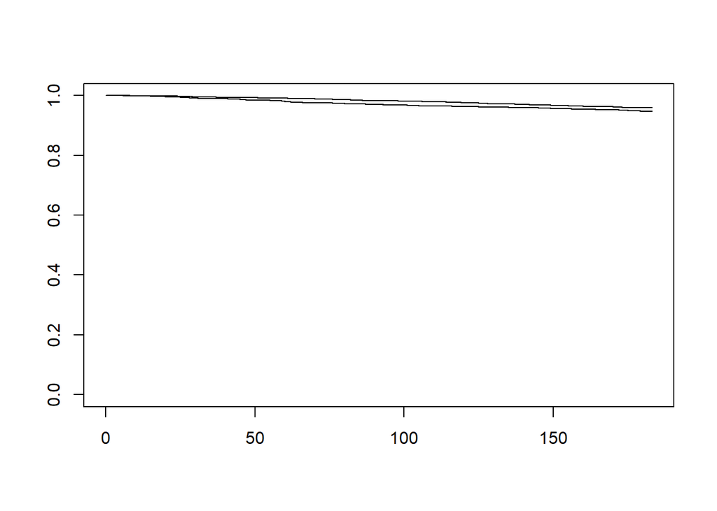

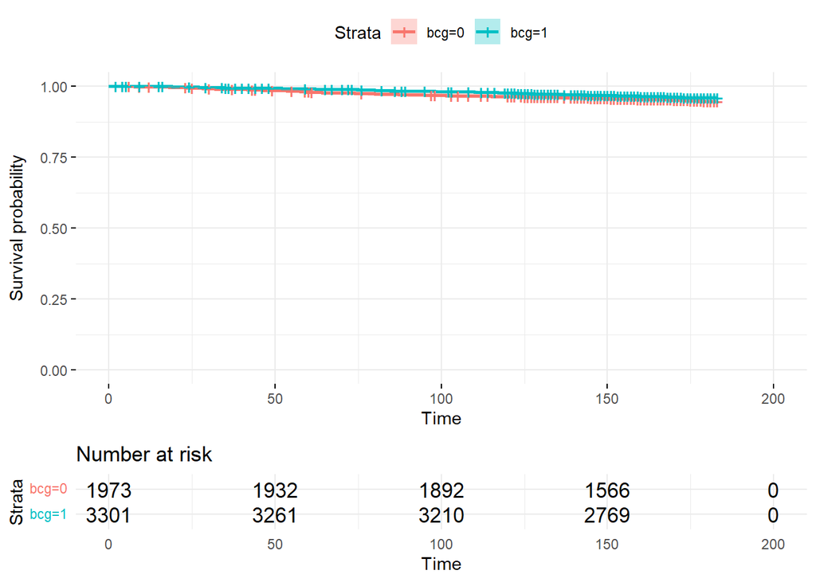

```r
#str(km_fit1)

#plot cummulative survival rate(probabilities)
plot(km_fit1)
ggsurvplot(km_fit1, data = bissau_data, risk.table = T, conf.int = T, ggtheme = theme_minimal())
```

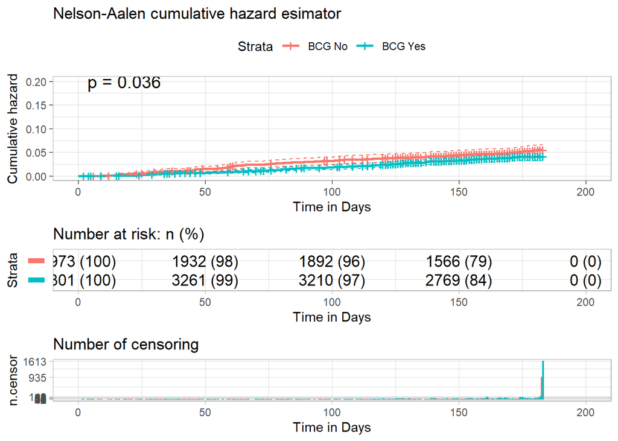

```r
#plot(km_fit1, mark.time = FALSE)
ggsurvplot(km_fit1,fun = "cumhaz",pval = T,conf.int = T,
           ggtheme = theme_light(),risk.table = "abs_pct", risk.table.y.text.col = T,risk.table.y.text = FALSE, ncensor.plot = TRUE,legend.labs = c("BCG No", "BCG Yes"),
           title= "Nelson-Aalen cumulative hazard esimator" ,
           xlab = "Time in Days", conf.int.style= "step",
           data = bissau_data)
```

```r
summary(km_fit1, times = c(30*(1:10)))
```

```
## Call: survfit(formula = Surv(fuptime, dead) ~ bcg, data = bissau_data,
##     type = "kaplan-meier")
##
##                 bcg=0
##  time n.risk n.event survival std.err lower 95% CI upper 95% CI
##    30   1952      17    0.991 0.00208        0.987        0.995
##    60   1924      22    0.980 0.00314        0.974        0.986
##    90   1899      20    0.970 0.00385        0.962        0.978
##   120   1870      13    0.963 0.00425        0.955        0.972
##   150   1566      12    0.957 0.00464        0.948        0.966
##   180   1020      12    0.948 0.00529        0.937        0.958
##
##                 bcg=1
##  time n.risk n.event survival std.err lower 95% CI upper 95% CI
##    30   3280      14    0.996 0.00113        0.994        0.998
##    60   3254      15    0.991 0.00163        0.988        0.994
##    90   3216      27    0.983 0.00226        0.979        0.987
##   120   3170      22    0.976 0.00266        0.971        0.981
##   150   2769      28    0.967 0.00314        0.961        0.973
##   180   1825      17    0.960 0.00352        0.954        0.967
```

### It is difficult to evaluate the effect of BCG vaccination from the Kaplan-Meier plot because of the scale. However, the effect is much evident using the Nelson-Aalen plot

```r
#Nelson-Aelen estimator
#cumsum(km_fit1$n.event/km_fit1$n.risk)
#plot(cumsum(km_fit1$n.event/km_fit1$n.risk))
#-log(km_fit1$surv)

#Nelson-Aelen
ne_fit1 <- summary(survfit(Surv(fuptime, dead)~ 1,
                   data = bissau_data, type="fleming-harrington"))
#print(ne_fit1)
#plot(ne_fit1,conf.int = F, data = bissau_data)

#list(ne_fit1$time, -log(ne_fit1$surv))
```

```r
km_fit2 <- survfit(Surv(fuptime, dead)~ bcg+agegrp,
                   data = bissau_data, type = "kaplan-meier")
print(km_fit2)
```

```
## Call: survfit(formula = Surv(fuptime, dead) ~ bcg + agegrp, data = bissau_data,
##     type = "kaplan-meier")
##
##                            n events median 0.95LCL 0.95UCL
## bcg=0, agegrp=<3 months 1373     69     NA      NA      NA
## bcg=0, agegrp=>3 months  600     28     NA      NA      NA
## bcg=1, agegrp=<3 months 1279     34     NA      NA      NA
## bcg=1, agegrp=>3 months 2022     91     NA      NA      NA
```

```r
summary(km_fit2, times = c(30*(1:10)))
```

```
## Call: survfit(formula = Surv(fuptime, dead) ~ bcg + agegrp, data = bissau_data,
##     type = "kaplan-meier")
##
##                 bcg=0, agegrp=<3 months
##  time n.risk n.event survival std.err lower 95% CI upper 95% CI
##    30   1362       8    0.994 0.00206        0.990        0.998
##    60   1345      16    0.982 0.00355        0.976        0.989
##    90   1324      17    0.970 0.00461        0.961        0.979
##   120   1300      12    0.961 0.00523        0.951        0.971
##   150   1095       8    0.955 0.00565        0.944        0.966
##   180    731       7    0.947 0.00631        0.935        0.960
##
##                 bcg=0, agegrp=>3 months
##  time n.risk n.event survival std.err lower 95% CI upper 95% CI
##    30    590       9    0.985 0.00497        0.975        0.995
##    60    579       6    0.975 0.00640        0.962        0.988
##    90    575       3    0.970 0.00700        0.956        0.984
##   120    570       1    0.968 0.00719        0.954        0.982
##   150    471       4    0.961 0.00807        0.945        0.977
##   180    289       5    0.948 0.00972        0.929        0.967
##
##                 bcg=1, agegrp=<3 months
##  time n.risk n.event survival std.err lower 95% CI upper 95% CI
##    30   1274       3    0.998 0.00136        0.995        1.000
##    60   1267       2    0.996 0.00175        0.993        1.000
##    90   1251      10    0.988 0.00303        0.982        0.994
##   120   1238       3    0.986 0.00332        0.979        0.992
##   150   1099      12    0.976 0.00435        0.967        0.984
##   180    742       4    0.972 0.00476        0.963        0.981
##
##                 bcg=1, agegrp=>3 months
##  time n.risk n.event survival std.err lower 95% CI upper 95% CI
##    30   2006      11    0.995 0.00164        0.991        0.998
##    60   1987      13    0.988 0.00242        0.983        0.993
##    90   1965      17    0.980 0.00315        0.973        0.986
##   120   1932      19    0.970 0.00380        0.963        0.978
##   150   1670      16    0.962 0.00433        0.953        0.970
##   180   1083      13    0.953 0.00490        0.943        0.963
```

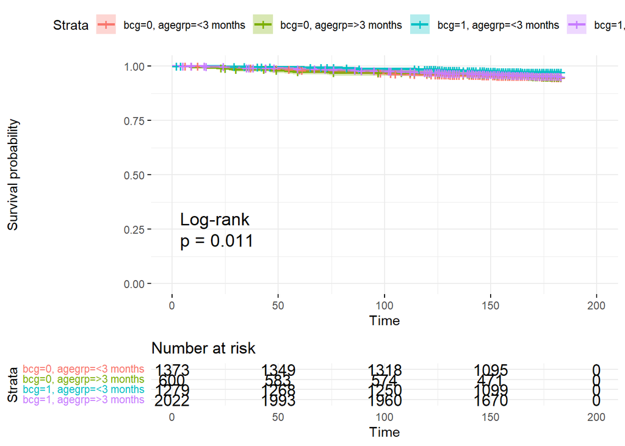

```r
ggsurvplot(km_fit2, data = bissau_data, risk.table = T, conf.int = T,pval = T,pval.method = T, ggtheme = theme_minimal())
```

```r
#run cox regression
cox_reg1 <- coxph(Surv(fuptime, dead)~ bcg,
                  data=bissau_data)
summary(cox_reg1)
```

```
## Call:
## coxph(formula = Surv(fuptime, dead) ~ bcg, data = bissau_data)
##
##   n= 5274, number of events= 222
##
##        coef exp(coef) se(coef)      z Pr(>|z|)
## bcg -0.2821    0.7542   0.1353 -2.085   0.0371 *
## ---
## Signif. codes:  0 '***' 0.001 '**' 0.01 '*' 0.05 '.' 0.1 ' ' 1
##
##     exp(coef) exp(-coef) lower .95 upper .95
## bcg    0.7542      1.326    0.5785    0.9832
##
## Concordance= 0.535  (se = 0.017 )
## Likelihood ratio test= 4.28  on 1 df,   p=0.04
## Wald test            = 4.35  on 1 df,   p=0.04
## Score (logrank) test = 4.38  on 1 df,   p=0.04
```

```r
exp(-0.2821)
```

```
## [1] 0.7541983
```

### The coefficient is the hazard ratio: which is the ratio between the hazard for vaccinated children (bcg =1) and the non-vaccinated children (bcg = 0). The hazard ratio is 0.75 (95% CI 0.58-0.98) and it is significantly different from 1.

```r
#run cox regression
cox_reg2 <- coxph(Surv(fuptime, dead)~ bcg+agegrp+dtp,
                  data=bissau_data)
summary(cox_reg2)
```

```
## Call:
## coxph(formula = Surv(fuptime, dead) ~ bcg + agegrp + dtp, data = bissau_data)
##
##   n= 5274, number of events= 222
##
##                     coef exp(coef) se(coef)      z Pr(>|z|)
## bcg             -0.40943   0.66403  0.16697 -2.452   0.0142 *
## agegrp>3 months  0.24128   1.27288  0.15492  1.557   0.1194
## dtp              0.05146   1.05280  0.10157  0.507   0.6124
## ---
## Signif. codes:  0 '***' 0.001 '**' 0.01 '*' 0.05 '.' 0.1 ' ' 1
##
##                 exp(coef) exp(-coef) lower .95 upper .95
## bcg                 0.664     1.5060    0.4787    0.9211
## agegrp>3 months     1.273     0.7856    0.9395    1.7245
## dtp                 1.053     0.9498    0.8628    1.2847
##
## Concordance= 0.554  (se = 0.018 )
## Likelihood ratio test= 8.26  on 3 df,   p=0.04
## Wald test            = 8.17  on 3 df,   p=0.04
## Score (logrank) test = 8.22  on 3 df,   p=0.04
```

```r
anova(cox_reg1,cox_reg2)
```

```
## Analysis of Deviance Table
##  Cox model: response is  Surv(fuptime, dead)
##  Model 1: ~ bcg
##  Model 2: ~ bcg + agegrp + dtp
##    loglik Chisq Df Pr(>|Chi|)
## 1 -1880.8
## 2 -1878.8 3.974  2     0.1371
```

```r
#proportional hazard assumption test
test.ph <- cox.zph(cox_reg2)
test.ph
```

```
##        chisq df     p
## bcg    4.913  1 0.027
## agegrp 0.116  1 0.733
## dtp    1.109  1 0.292
## GLOBAL 5.083  3 0.166
```

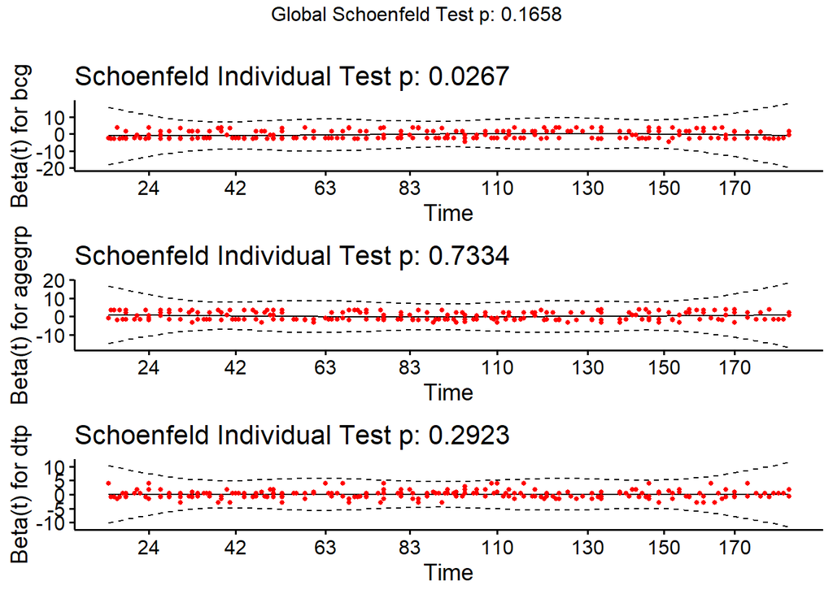

```r
#Global Schoenfeld Test: 0.166
ggcoxzph(test.ph)
```

The adjusted effect of vaccination is 0.66% (95% CI 0.48 - 0.92). There is a strong confounding effect of DTP and age.